# Speed Dating Analysis

Shannon McNish

November 28, 2016

## Introduction

This dataset was compiled by Columbia Business School professors Ray Fisman and Sheena Iyengar for their paper Gender Differences in Mate Selection: Evidence From a Speed Dating Experiment. Data was gathered from participants in experimental speed dating events from 2002-2004. During the events, the attendees would have a four minute “first date” with every other participant of the opposite sex. At the end of their four minutes, participants were asked if they would like to see their date again. They were also asked to rate their date on six attributes: Attractiveness, Sincerity, Intelligence, Fun, Ambition, and Shared Interests.

## Prepare Data

### load libraries

```r
library(ggplot2)
library(wesanderson) #for color palletes
library(plyr)
```

### set working directory

```r
setwd("C:/Users/smcnish/Documents/Vizs/Dating")
```

### read data

```r
allData = read.csv(file="Speed Dating Data.csv", header=TRUE)
```

### keep only variables you want

```r
keepvars<- c("iid", "gender", "wave", "position", "pf_o_att",
             "pf_o_sin","pf_o_int","pf_o_fun","pf_o_amb","pf_o_sha",
             "dec_o","attr_o", "sinc_o", "intel_o", "fun_o", "amb_o",
             "shar_o","date_3")

data<-allData[keepvars]
```

### factor variables

```r
fact<- c("gender", "dec_o","date_3")

data[fact] <- lapply(data[fact] , factor)

levels(data[,"gender"])<- c("Female","Male")
levels(data[,"dec_o"])<- c("No","Yes")
data$dec_o <- factor(data$dec_o, c("Yes", "No"))
levels(data[,"date_3"])<- c("No","Yes")
data$date_3 <- factor(data$date_3, c("Yes", "No"))
```

## Did men or women recieve more yes’s?

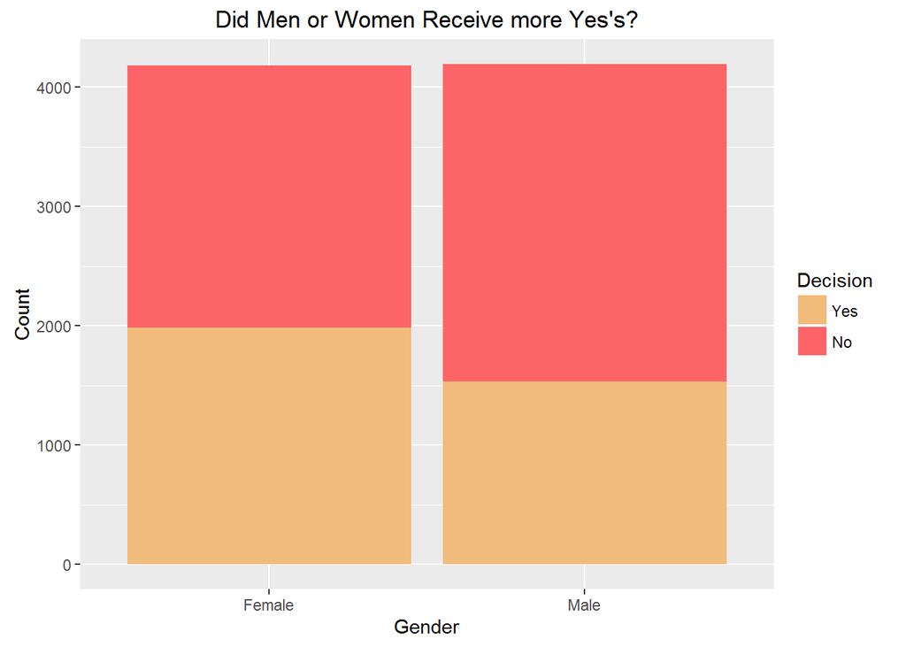

```r
ggplot(data, aes(gender, fill=dec_o)) + geom_bar() +
    ggtitle("Did Men or Women Receive more Yes's?") + labs(x="Gender",y="Count") +
    scale_fill_manual(name = "Decision", values=wes_palette(n=2, name="GrandBudapest"))
```

It looks like women recieved more yes’s than men. Perhaps women are more picky when making a decision?

## How many of the Yes decisions led to a date?

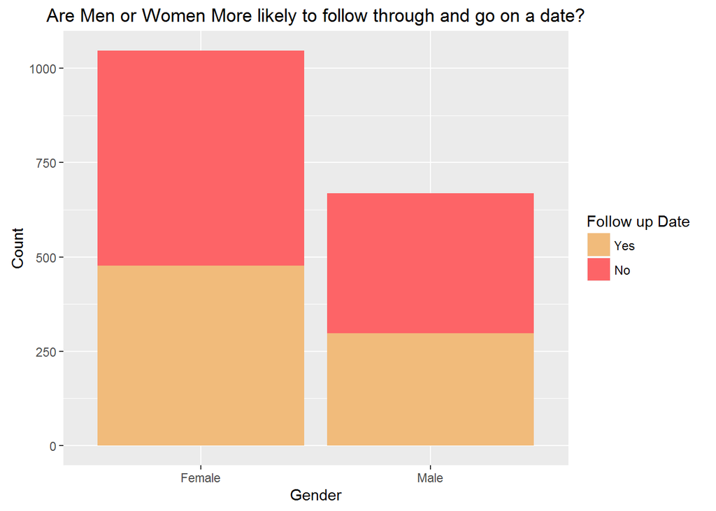

```r
data_yes2<-subset(data, subset=(dec_o=="Yes")&(!is.na(date_3)))

ggplot(data_yes2, aes(gender, fill=date_3)) + geom_bar() +
    ggtitle("Are Men or Women More likely to follow through and go on a date?") + labs(x="Gender",y="Count") +
    scale_fill_manual(name = "Follow up Date", values=wes_palette(n=2, name="GrandBudapest"))
```

It looks like more women followed through with dates, however the respose rate was greater for women than men

## What position were people more likely to get a yes?

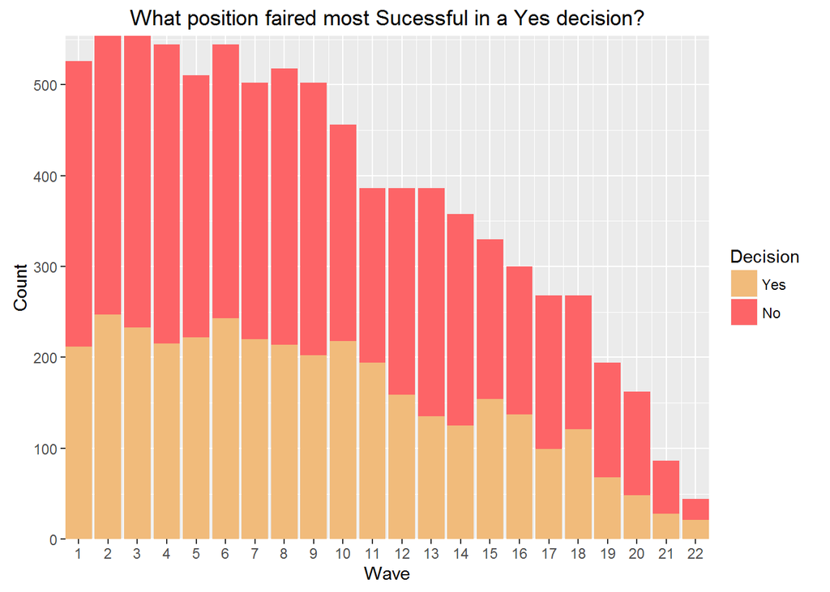

```r
ggplot(data, aes(position, fill=dec_o)) + geom_bar() +
  ggtitle("What position faired most Sucessful in a Yes decision?") + labs(x="Wave",y="Count") +
  scale_fill_manual(name = "Decision", values=wes_palette(n=2, name="GrandBudapest")) +
  scale_x_continuous(expand = c(0, 0), breaks = scales::pretty_breaks(n = 20)) +
  scale_y_continuous(expand = c(0, 0))
```

This is hard to compare since differnt waves had a different number of positions. Let’s get just the last position of each wave

### compare first position to last position of wave

There is no position 1 in wave 17, so we will code position 2 as for that wave for easy comparison

```r
data17<- within(data, position[position == 2 & wave == 17] <- 1)
pos1 <- subset(data17, subset = (position ==1))
```

Get data for only last position in each wave

```r
maxpos<- setNames(aggregate(data$position, by = list(data$wave), max),c("wave","position"))

pos.last <-  subset(merge(data,maxpos), position == position & wave == wave)
pos.last$position <- "Last"
```

Append data for first and last postiions into one data frame and plot

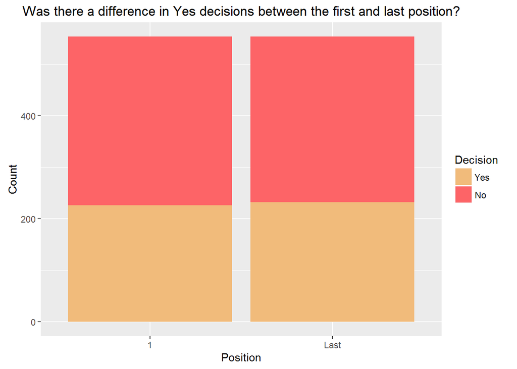

```r
data1.last<-rbind(pos1, pos.last)
data1.last$position <- as.factor(data1.last$position)


ggplot(data1.last, aes(position, fill=dec_o)) + geom_bar() +
  ggtitle("Was there a difference in Yes decisions between the first and last position?") + labs(x="Position",y="Count") +
  scale_fill_manual(name = "Decision", values=wes_palette(n=2, name="GrandBudapest"))
```

It looks like an equal distribution between those in the first vs last position in each wave